# VL04: Minimax, alpha-beta-Pruning

IFM 5.14 Künstliche Intelligenz, W19

Carsten Gips, FH Bielefeld

# Wiederholung

## Lokale Suche

1. Wie funktioniert die Gradientensuche?
2. Wie funktionieren Genetische Algorithmen?
3. Was ist der Unterschied zwischen GA und ES?

# Motivation

## Backgammon: Weiss hat 6+5 gewürfelt und hat 4 legale Züge

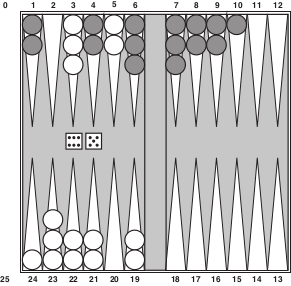

Quelle: (Russell und Norvig 2014)

**Was ist der beste Zug?!**

## Themen für heute

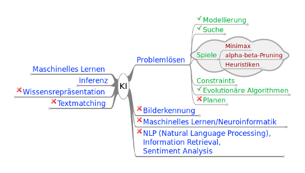

Am Ende der VL können/verstehen Sie:

- Berechnen optimaler Spielzüge mit Minimax
- Abschneiden von Pfaden mit Verschlechterung

# Optimale Spiele: Minimax-Algorithmus

## Motivation: Unterschied zu Suche?!

=> Mehrere **konkurrierende** Agenten an Suche beteiligt!

=> (Re-) Aktion des Gegners unbekannt/nicht vorhersehbar.

## Spiele und Umgebungen

|  | Deterministisch | Zufallskomponente |
| --- | --- | --- |
| Voll beobachtbar | Schach, Go, … | Backgammon, Monopoly |
| Partiell beobachtbar | Schiffe-versenken | Bridge, Poker, Skat, … |

=> Bis auf Roboterfußball in KI traditionell keine physischen Spiele!

## Brettspiele sind interessant für KI

- Brettspiele gut abstrakt darstellbar:
  - Zustände einfach repräsentierbar
  - Aktionen wohldefiniert (und i.d.R. sehr einfach)
  - Realisierung als Suchproblem möglich
- **Problem**: Suchbäume werden in Praxis riesig
  - **Schach**: Im Mittel 35 Aktionen von jeder Position; oft mehr als 50 Züge pro Spieler (Suchbäume mit mehr als 100 Ebenen): $35^{100} \approx 10^{154}$ mögliche Knoten!
  - **Go**: Im Mittel 200 Aktionen; mehr als 300 Züge: $200^{300} \approx 10^{700}$ Knoten im Suchbaum!

  Quelle: (Russell und Norvig 2014)

## Eigenschaften guter Spielalgorithmen

- Zeit begrenzt
  - Irgendeine gute Entscheidung treffen! => Bewertungsfunktion (auch für Zwischenzustände)
- Speicher begrenzt
  - Evaluierungsfunktion für Zwischenzustände
  - Löschen von irrelevanten Zweigen
- Strategien nötig
  - Vorausschauend spielen (Züge “vorhersehen”)

## Spiele als Suchproblem: Minimax

### Terminologie

- Zwei abwechselnd spielende Spieler: `MAX` und `MIN`, wobei `MAX` beginnt
  - Beide Spieler spielen in jedem Zug optimal
  - Spielergebnis wird aus Sicht von `MAX` bewertet:
    - $+1$, wenn Spieler `MAX` gewinnt
    - $-1$, wenn Spieler `MIN` gewinnt
    - $0$, wenn unentschieden
  - Spieler `MAX` versucht, das Spielergebnis zu **maximieren**
  - Spieler `MIN` versucht, das Spielergebnis zu **minimieren**
- Startzustand: Initialer Zustand des Spielbrettes
- Aktionen: Legale Züge, abhängig vom Spielzustand
- Zieltest: Ist das Spiel vorbei?

  => Startzustand und anwendbare Aktionen definieren den Zustandsraum.
- Nutzenfunktion: $\operatorname{UTILITY}(s,p)$: Wert des Spiels für Spieler $p$ im Spielzustand $s$
- Strategie: Spieler benötigen **Strategie**, um zu gewünschtem Endzustand zu kommen *(unabhängig von den Entscheidungen des Gegenspielers)* => einfacher Pfad von Start zu Ziel reicht nicht

*Hinweis*: Nullsummenspiel!

Eine mit dem Minimax-Algorithmus berechnete Strategie wird auch *Minimax-Strategie* genannt. Sie sichert dem betreffenden Spieler den höchstmöglichen Gewinn, der **unabhängig** von der Spielweise des Gegners erreichbar ist.

Bei Nicht-Nullsummenspielen, bei denen die Niederlage des Gegners nicht zwangsläufig mit dem eigenen Gewinn zusammenfällt (d.h. Gewinn des einen Spielers $\ne$ Verlust des anderen Spielers), liefert der Minimax-Algorithmus nicht unbedingt eine optimale Strategie.

### Spielbaum TTT

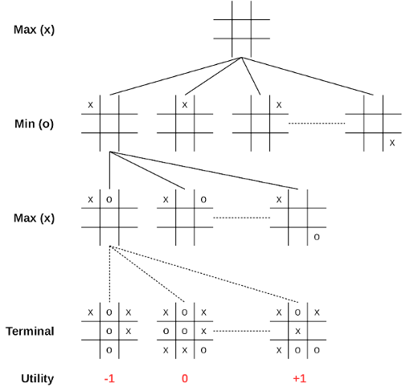

### Minimax (Idee)

1. Erzeuge kompletten Suchbaum mit Tiefensuche
2. Wende Nutzenfunktion (*Utility*) auf jeden Endzustand an
3. Ausgehend von Endzuständen => Bewerte Vorgängerknoten:
   - Knoten ist `Min`-Knoten: Nutzen ist das **Minimum** der Kindknoten
   - Knoten ist `Max`-Knoten: Nutzen ist das **Maximum** der Kindknoten
4. Startknoten: `Max` wählt den Zug, der zum Nachfolger mit der höchsten Bewertung führt

*Annahme*: Beide spielen perfekt. Fehler verbessern das Resultat für den Gegner.

## Minimax-Algorithmus: Funktionen für MAX- und MIN-Knoten

```python
def Max-Value(state):
    if Terminal-Test(state): return Utility(state)

    v = -INF
    for (a, s) in Successors(state):
        v = MAX(v, Min-Value(s))
    return v
```

```python
def Min-Value(state):
    if Terminal-Test(state): return Utility(state)

    v = +INF
    for (a, s) in Successors(state):
        v = MIN(v, Max-Value(s))
    return v
```

*Hinweis*: In der Literatur finden Sie auch eine Variante mit einem zusätzlichen Tiefenparameter, um bei einer bestimmten Suchtiefe abbrechen zu können.

Wenn man ohne Suchtiefenbeschränkung arbeiten will, braucht man diesen Parameter nicht! Der Algorithmus terminiert auch ohne Suchtiefenbeschränkung!

## Minimax-Algorithmus: Sonderbehandlung Startknoten

```python
def Minimax(state):
    (val, action) = (-INF, null)
    for (a, s) in Successors(state):
        v = Min-Value(s)
        if (val <= v):
            (val, action) = (v, a)
    return action
```

- Startknoten ist ein MAX-Knoten
- Nicht nur Kosten, sondern auch die zugehörige Aktion speichern

## Minimax Beispiel

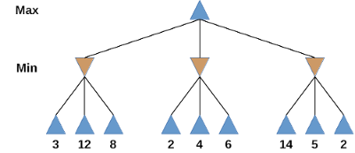

Tafelbeispiel Handsimulation

### Aufwand Minimax

- maximale Tiefe des Spielbaums: $m$
- in jedem Zustand $b$ gültige Züge
- => Zeitkomplexität $O(b^m)$

erster Zug: $b$ Möglichkeiten zweiter Zug: jeweils wieder $b$ Möglichkeiten $\rightarrow$ $b*b = b^2$ dritter Zug: jeweils wieder $b$ Möglichkeiten $\rightarrow$ $b*(b*b) = b^3$ … $m$. Zug: jeweils wieder $b$ Möglichkeiten $\rightarrow$ $b^m$

## Wenn die Zeit nicht reicht: Suchtiefe begrenzen

- Einführung neuer Funktionen:
  1. `Cutoff-Test` statt `Terminal-Test`

     Beispielsweise bei erreichter Tiefe oder Zeitüberschreitung
  2. `Eval` statt `Utility`

     Bewertung der erreichten Position (statt nur Bewertung des Endzustandes)
- Bedingungen an `Eval`:
  - Endknoten in selber Reihenfolge wie bei `Utility`
  - Schnell zu berechnen (!)

## Beispiel Schach

- Mögliche Evaluierungskriterien:
  - Materialwert: Bauer 1, Läufer/Springer 3, Turm 5, Dame 9
  - Stellungsbewertung: Sicherheit des Königs, Stellung der Bauern
  - Daumenregeln: 3 Punkte Vorteil => sicherer Sieg
- Nutzung gewichteter Features $f_i$: $\operatorname{Eval}(s) = w_1f_1(s) + w_2f_2(s) + \ldots$
  - Beispiel: $w_1 = 9$ und $f_1(s)$ = (# weiße Königinnen) - (# schwarze Königinnen)
- **Alternativ**: Speicherung von Positionen plus Bewertung in Datenbanken => Lookup mit $\operatorname{Eval}(s)$

## Minimax mit mehreren Spielern

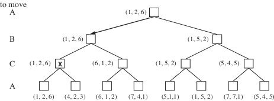

Quelle: (Russell und Norvig 2014)

## Zufallsspiele

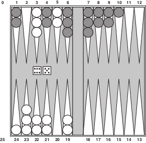

Quelle: (Russell und Norvig 2014)

Backgammon: Weiss hat 6+5 gewürfelt und hat 4 legale Züge.

## Minimax mit Zufallsspielen: ZUFALLS-Knoten

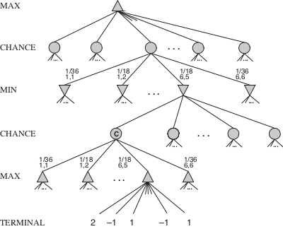

Quelle: (Russell und Norvig 2014)

Zusätzlich zu den MIN- und MAX-Knoten führt man noch Zufalls-Knoten ein, um das Würfelergebnis repräsentieren zu können. Je möglichem Würfelergebnis $d_i$ gibt es einen Ausgang, an dem die Wahrscheinlichkeit $P(d_i)$ dieses Ausgangs annotiert wird.

=> Für Zufallsknoten *erwarteten* Minimax-Wert (*Expectimax*) nutzen

## Minimax mit Zufall: Expectimax

Expectimax-Wert für Zufallsknoten $C$ (für `Max`-Spieler):

$$\operatorname{Expectimax}(C) = \sum_i P(d_i) \max_{s \in S(C,d_i)} \operatorname{Utility}(s)$$

- $d_i$ mögliches Würfelergebnis
- $P(d_i)$ Wahrscheinlichkeit für Würfelergebnis
- $S(C,d_i)$ Erreichbare Spielzustände von $C$ aus (gegeben $d_i$)
- $\operatorname{Utility}(s)$ Bewertung von Spielzustand $s$

# Gezielt faul sein: alpha-beta-Pruning

## Verbesserung Minimax-Algorithmus

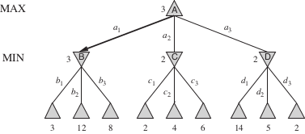

Quelle: (Russell und Norvig 2014)

=> **Minimax-Baum**: Verbesserungen möglich?

Tafelbeispiel: Baum und Verbesserungen

## alpha-beta-Pruning

Minimax-Algorithmus mit zusätzlichen Informationen:

- $\alpha$: bisher bester Wert für MAX (höchster Wert)
- $\beta$: bisher bester Wert für MIN (kleinster Wert)

=> Beobachtungen:

- $\alpha$-Wert für MAX-Knoten wird nie kleiner
- $\beta$-Wert für MIN-Knoten wird nie größer

Tafelbeispiel: Beste Werte einzeichnen

## Pruning-Regeln

1. Schneide (unter) MIN-Knoten ab, deren $\beta$-Wert kleiner/gleich dem $\alpha$-Wert des MAX-Vorgängers ist.
2. Schneide (unter) MAX-Knoten ab, deren $\alpha$-Wert größer/gleich dem $\beta$-Wert des MIN-Vorgängers ist.

“Abbruch, wenn kein Platz mehr zwischen Alpha und Beta”

## alpha-beta-Pruning – Der Algorithmus (Skizze)

```python
def Max-Value(state, alpha, beta):
    if Terminal-Test(state): return Utility(state)

    v = -INF
    for (a, s) in Successors(state):
        v = MAX(v, Min-Value(s, alpha, beta))
        if (v >= beta): return v
        alpha = MAX(alpha, v)
    return v
```

```python
def Min-Value(state, alpha, beta):
    if Terminal-Test(state): return Utility(state)

    v = +INF
    for (a, s) in Successors(state):
        v = MIN(v, Max-Value(s, alpha, beta))
        if (v <= alpha): return v
        beta = MIN(beta, v)
    return v
```

Initialer Aufruf von `Max-Value()` mit $\alpha = -\infty$ und $\beta = +\infty$

**Achtung**: Es kursieren Varianten von diesem Algorithmus, bei denen auf die Hilfsvariable `v` verzichtet wird und stattdessen `alpha` bzw. `beta` direkt modifiziert werden und als Rückgabewert dienen. Das *kann* zu falschen Ergebnissen führen! Sie können das in der Aufgabe auf B04 gut sehen.

Tafelbeispiel Handsimulation

## alpha-beta-Pruning – Eigenschaften

- Pruning beeinflusst nicht das Endergebnis!
- Sortierung der Nachfolger spielt große Rolle
- Perfekte Sortierung: $O(b^{d/2})$ => Verdopplung der Suchtiefe möglich

Für Schach immer noch zu aufwändig …

## Verbesserungen für alpha-beta-Pruning

- “Killer-Move”: Maximale Effizienz nur wenn optimaler Zug immer zuerst untersucht => Zu untersuchende Züge **sortieren/priorisieren**, zb. Schach:
  1. Figuren schlagen
  2. Drohen
  3. Vorwärts ziehen
  4. Rückwärts ziehen
- Verändern der Suchtiefe nach Spielsituation
- Bewertungsfunktion `Eval`:
  - Datenbanken mit Spielsituationen und Expertenbewertung:
    - Eröffnungsspiele (besonders viele Verzweigungen)
    - Endspiele
  - Lernen der optimalen Gewichte für `Eval`-Funktion
  - Berücksichtigung von Symmetrien

## Beispiel DeepBlue (IBM, 1997)

- Alpha-beta-Pruning mit Tiefenbeschränkung: ca. 14 Halbzüge
- Dynamische Tiefenbeschränkung (stellungsabhängig, max. ca. 40 Züge)
- Heuristische Stellungsbewertung:
  - mehr als 8.000 Features
  - ca. 4.000 Eröffnungsstellungen
  - ca. 700.000 Spielsituationen
  - Endspiel-Datenbank: alle Spiele mit 5 Steinen, viele mit 6 Steinen

Quelle: (Russell und Norvig 2014)

## Beispiel AlphaGo (Google, 2016)

- Beschränkung der Suchtiefe: Bewertung der Stellung durch *“Value Network”*
- Beschränkung der Verzweigungsbreite: Bestimmung von Zugkandidaten durch *“Policy Network”*
- Training dieser *“Deep Neural Networks”*:
  - Überwachtes Lernen: “Analyse” von Spiel-Datenbanken
  - Reinforcement-Lernen: Self-Play, Bewertung am Ende
    - Züge mit Monte-Carlo-Baumsuche ausgewählt

Quelle: (Silver u. a. 2016), siehe auch [deepmind.com/research/alphago/](https://deepmind.com/research/case-studies/alphago-the-story-so-far)

# Zusammenfassung

## tl;dr

- Minimax:
  - Minimax entwickelt Spielbaum, bewertet Zustände entsprechend `Max` und `Min`
  - Erweiterung auf $>2$ Spieler
  - Erweiterung auf Spiele mit Zufall
- Alpha-beta-Pruning:
  - Mitführen der bisher besten Werte für MAX und MIN: $\alpha$ und $\beta$
  - Abschneiden von Pfaden, die Verschlechterung bewirken würden
  - Endergebnis bleibt erhalten
  - Effizienzsteigerung abhängig von Sortierung der Nachfolger
- Viele Verbesserungen denkbar:
  - Zu untersuchende Züge “richtig” sortieren (Heuristik)
  - Suchtiefe begrenzen und Bewertungsfunktion (statt Nutzenfunktion)
  - Positionen mit Datenbank abgleichen

**Nächste Woche**: Constraints, AC-3

## Literatur zum Weiterlesen

- Russell und Norvig (2014):
  - Minimax: Abschnitte 5.1 und 5.2
  - Alpha-beta-Pruning: Abschnitt 5.3
  - Erweiterungen: Abschnitte 5.3 – 5.8

### Bibliographie

Russell, S.; und P. Norvig. 2014. *Artificial Intelligence: A Modern Approach*. 3rd revised edition. Pearson. ISBN: 978-1-292-02420-2. URL: http://aima.cs.berkeley.edu (zugegriffen 17.07.2018).

Silver, D. u. a. 2016. „Mastering the game of Go with deep neural networks and tree search“. *nature* 529 (7587): 484. DOI: 10.1038/nature16961. URL: https://storage.googleapis.com/deepmind-media/alphago/AlphaGoNaturePaper.pdf (zugegriffen 24.07.2018).

## Lernziele – Nach dieser Vorlesung sollten Sie …

### Verstehen (K2)

- Minimax für mehr als zwei Spieler
- Minimax mit Zufallskomponente
- Optimierungsmöglichkeiten für Minimax:
  - Sortierung der Nachfolger => Heuristik
  - Suchtiefe beschränken => Übergang zu Bewertungsfunktion
  - Bewertung über Spieldatenbanken

### Anwenden (K3)

- Minimax-Algorithmus
- Alpha-beta-Pruning
- Tiefenbeschränkung und Bewertungsfunktion bei Minimax

## Diese Fragen sollten Sie beantworten können …

### Spielbaum, Minimax-Bewertung

Zeichnen Sie den Spielbaum für das Spiel “Nimm” auf. Bewerten Sie die Spielzustände mit dem Minimax-Algorithmus.

**Nimm**:

- Initial 5 Hölzer
- In jedem Zug müssen 1-2 Hölzer genommen werden
- Wer das letzte Holz nimmt, verliert

Beschränken Sie die Suchtiefe auf 2 Züge und geben Sie eine sinnvolle Bewertungsfunktion an. Wie ändert sich die Bewertung der Zustände durch Minimax?

### Erweiterungen von Minimax

- Wie verhält sich der Minimax-Algorithmus, wenn der Spieler `MIN` suboptimal spielt?
- Vollziehen Sie den alpha-beta-Pruning-Algorithmus von Hand am Beispiel aus der VL nach.
- Wie kann man mit Minimax Spiele mit mehreren Spielern spielen?
- Wie muss man Minimax erweitern, um Spiele mit Zufall zu berücksichtigen?
- Vereinfachen Sie den Minimax-Algorithmus aus der Vorlesung, indem Sie die Eigenschaft Nullsummenspiel berücksichtigen und die Funktionen `Min-Value` und die `Max-Value` in eine einzige Funktion ohne explizite Unterscheidung der Spieler zusammenfassen.